# Categorical Dependent Variables

# Overview

Until now, we have been limited to using numeric variables as our dependent variables. In this notebook we look at how we can use OLS modeling for categorical dependent variables with the **linear probability model**, as well as the related **logit** and **probit** models. This set of models is designed for looking at **dichotomous** dependent variables, variables with only 2 possible outcomes. These types of outcomes are of the sort that can be answered as a yes or no type question, for example:

- Was a job candidate hired?
- Did a customer make a purchase?
- Was a patient cured?
- Did a product break?
- Did a politician vote for a specific bill?

As you might be starting to suspect, there are tons of interesting questions that can be answered with these types of models!

While not often utilized in economics, there are versions of probit and logit that are designed for **multinomial** (categorical variables with more than 2 outcomes) and **ordered** (multinomial variables whose levels can be ordered from worst to best, lowest to highest, etc.) dependent variables.

Let’s begin by loading in some essential packages. We have not yet used `margins`, `jtools`, `mlogit`, or `MASS`, so you may need to install those now. Additionally, `jtools` requires a couple more packages to be installed to do what we will be asking it to do, `broom` and `huxtable`:

```r
install.packages("margins")
install.packages("jtools")
install.packages("broom")
install.packages("huxtable")
install.packages("mlogit")
install.packages("MASS")
```

```r
library(tidyverse)
library(stargazer)
library(margins)
library(mlogit)
library(MASS)
library(jtools)
library(wooldridge)
library(AER)
data(k401ksubs)
data(SmokeBan)
data(affairs)
data(HousePrices)
data(diamonds)
data(gpa2)
data(TeachingRatings)
data(CPS1988)
```

# Linear Probability Model

The linear probability model (LPM) is the easiest place to begin – while the model is generally thought to be inferior to probit or logit, estimating and interpreting the model is far more straightforward because it essentially just an OLS regression with a dummy variable as our dependent variable.

Let’s start with a simple bivariate model; it should help develop the intuition of predicting dichotomous outcomes without getting too complicated too quickly. We will use the `k401ksubs` dataset in the `wooldridge` package, which contains 9275 individual level observations. We will start by seeing whether or not income level, `inc` is predictive of whether or not an individual participates in a 401k account, captured in the `p401k` variable.

Let’s start by just putting the two variables we are going to analyze into a smaller dataframe called `retdata` and look at some summary statistics.

```r
retdata <- k401ksubs %>% select(inc, p401k)
summary(retdata)
```

```
      inc             p401k
 Min.   : 10.01   Min.   :0.0000
 1st Qu.: 21.66   1st Qu.:0.0000
 Median : 33.29   Median :0.0000
 Mean   : 39.25   Mean   :0.2762
 3rd Qu.: 50.16   3rd Qu.:1.0000
 Max.   :199.04   Max.   :1.0000
```

How do we interpret the results of the `p401k` variable? Because it is coded as a dummy variable, `p401k=1` tells us that an individual has a 401k account, and `p401k=0` tells us they do not. The mean of 0.2762264 tells us that 27.6% of the individuals in the data set have a 401k account. We can look to see if there is a different mean income of the two groups:

```r
retdata %>% group_by(p401k) %>%
    summarize(mean = mean(inc))
```

| p401k | mean |
| --- | --- |
| 0 | 35.22425 |
| 1 | 49.81514 |

As a reminder, we could have gotten the same summary statistics using `mean(retdata$inc[retdata$p401k == 0])` and `mean(retdata$inc[retdata$p401k == 1])`. These results do suggest that individuals who participate in their company’s 401k program tend to have higher incomes on average.

The **linear probability model** is simple to estimate; we run a regression using `p401k` as our dependent variable with `inc` as the sole independent variable.

Luckily, the `k401ksubs` data has coded the `p401k` variable as a dummy for us already; if it were not and instead was coded as a factor, we would need an extra step (e.g. we could create a dummy variable using the `ifelse()` command, we could use the `as.numeric()` command, etc.). We will see examples of this sort later!

```r
reg1a <- lm(p401k ~ inc, data = k401ksubs)
stargazer(reg1a, type = "text")
```

```
===============================================
                        Dependent variable:
                    ---------------------------
                               p401k
-----------------------------------------------
inc                          0.005***
                             (0.0002)

Constant                     0.079***
                              (0.009)

-----------------------------------------------
Observations                   9,275
R2                             0.073
Adjusted R2                    0.073
Residual Std. Error      0.430 (df = 9273)
F Statistic          734.022*** (df = 1; 9273)
===============================================
Note:               *p<0.1; **p<0.05; ***p<0.01
```

What does this result tell us? The $\hat{\beta} = .005$ tells us that, for every $1,000 increase in income, the expected probability of an individual participating in the 401k program increases by half a percentage point.

$$\begin{equation}
Probability\:of\:401k\:Participation_{i} = .079 + .005 \cdot income_i
\end{equation}$$

Just as with a regression, we can calculate a predicted probability by plugging in values for $income_i$; for example, we would estimate that somebody with $50,000 income ($inc_i=50$), as:

$$\begin{equation}
Probability\:of\:401k\:Participation_{i} = .079 + .005 \cdot 50 = 32.9\%
\end{equation}$$

What if we wanted to predict the probability of 401k participation for somebody with an income of $190,000 ($inc_i=190$)

$$\begin{equation}
Probability\:of\:401k\:Participation_{i} = .079 + .005 \cdot 190 = 102.9\%
\end{equation}$$

Somehow the model gives this individual a greater than 100% chance of participating in their company’s 401k program, which is a problem, especially considering that $inc_i=190$ isn’t extrapolation.

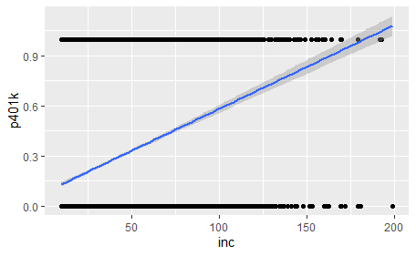

```r
k401ksubs %>% ggplot(aes(x = inc, y = p401k)) +
    geom_point() +
    geom_smooth(method = lm)
```

A second problem with the LPM becomes apparent when examining the Q-Q plot. Recall, the Q-Q plot examines the residuals of the model, and the Q-Q plot is expected to be a relatively straight line. For a the linear probability model, it will almost certainly never be so:

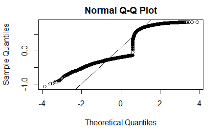

```r
qqnorm(reg1a$residuals)
qqline(reg1a$residuals)
```

This is a funky looking graph, but this level of heteroskedasticity is completely expected for a linear probability model; you are predicting a probability, so most of your predictions are between 0 and 1. However, the outcome variable `p401k` can ONLY be 0 or 1. This pretty much guarantees that you will have too many huge outliers.

Estimating a **logit** or **probit** model mitigates both of these problems. Estimating these models are fairly straightforward and require the `glm()` command; GLM stands for **Generalized Linear Model**. Let’s estimate both the logit and probit models:

```r
reg1b <- glm(p401k ~ inc, family = binomial(link = "logit"), data = k401ksubs)
reg1c <- glm(p401k ~ inc, family = binomial(link = "probit"), data = k401ksubs)
```

The syntax for these are very similar to the syntax for `lm`; the function is specified in the same way (`p401k ~ inc`), the data is specified in the same way (`data = k401ksubs`), the only difference is that you need to specify the `family` option.

While estimating the model is fairly straightforward, interpreting the results is not. Let’s look at the 3 results, side-by-side:

```r
stargazer(reg1a, reg1b, reg1c, type = "text")
```

```
===================================================================
                                  Dependent variable:
                    -----------------------------------------------
                                         p401k
                               OLS             logistic    probit
                               (1)               (2)        (3)
-------------------------------------------------------------------
inc                         0.005***           0.024***   0.015***
                            (0.0002)           (0.001)    (0.001)

Constant                    0.079***          -1.966***  -1.197***
                             (0.009)           (0.049)    (0.028)

-------------------------------------------------------------------
Observations                  9,275             9,275      9,275
R2                            0.073
Adjusted R2                   0.073
Log Likelihood                                -5,144.242 -5,139.835
Akaike Inf. Crit.                             10,292.480 10,283.670
Residual Std. Error     0.430 (df = 9273)
F Statistic         734.022*** (df = 1; 9273)
===================================================================
Note:                                   *p<0.1; **p<0.05; ***p<0.01
```

Some things stand out. The $R^2$ in this model has been replaced by the log likelihood and the AIC, and the estimated $\hat{\alpha}$ and $\hat{beta}$ look very different from those of the linear model. Interpreting $\hat{\alpha}$ and $\hat{beta}$ in this form is quite difficult; it requires wrapping ones mind around the concept of log-likelihood and odds ratios and other such things. If you are just interested in predictive modeling, these results are sufficient. But for the sake of learning how to interpret the model, we will learn how to convert these coefficients to a format that is interpreted like OLS coefficients shortly.

First though, let’s look at a graph of what we just estimated.

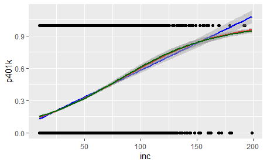

```r
k401ksubs %>% ggplot(aes(x = inc, y = p401k)) +
    geom_point() +
    geom_smooth(method = lm, color = "blue") +
    stat_smooth(method = "glm",
                method.args = list(family = binomial(link = "probit")),
                color = "red") +
    stat_smooth(method = "glm",
                method.args = list(family = binomial(link = "logit")),
                color = "darkgreen")
```

The blue line is the linear model that we plotted earlier, the red and green lines are the probit and logit models respectively. Some points of note:

- The probit and logit models are very similar to each other. Logit is often preferred in disciplines like biostats, because the logit coefficients have a useful interpretation in terms of odds ratios. Generally speaking, there may be a slight preference for probit in economics, but for the most part, it doesn’t much matter which one you use.
- The probit and logit models are clearly non-linear, and they will asymptotically approach 0 and 1 but will never actually hit 0 or 1.

The fact that the model is non-linear provides a useful place to think about the concept of the **margin**. In economics, the idea of “marginal” is very similar to the idea of “additional”; for example, the marginal cost of production is the additional cost incurred from producing one more item, marginal utility is the additional utility received from consuming a tiny bit more, and so on. With that in mind, the estimated values of $\hat{\beta}$ from an OLS regression have a very similar interpretation – a small, one unit change in your $X$ variable leads to a $\hat{\beta}$ sized increase in your $Y$ variable. In the linear model, the value of $\hat{\beta}$ is constant; that is, regardless of the value of $X$, the marginal effect of $X$ on $Y$ is the same: $\hat{\beta}$. In a non-linear model like probit or logit, the marginal effect of $X$ on $Y$ varies by the value of $X$; where the curve is relatively flat, the marginal effect of $X$ on $Y$ is relatively small, whereas when the curve is relatively steep, the marginal effect of $X$ on $Y$ is relatively large.

The upshot of all of this is that it takes some work to be able to interpret our probit and logit estimates in the same way we interpret our OLS estimates. To do so, we need to obtain **marginal effects** from our probit and logit model. Luckily, there are multiple packages we can install that will do all the work for us. We will use the `margins` package.

There are two primary methods of calculating marginal effects:

- **Marginal Effect at the Means (MEM)** – find the mean of all of your independent variables, and calculate the marginal effect of each variable at that point.
- **Average Marginal Effect (AME)** – find the marginal effect for every observation in the data, and calculate the mean of those marginal effects.

MEM is easier to calculate, though in my opinion AME is the more generally appropriate method. By default, `margins` uses the AME option. The syntax for the `margins()` function is quite simple – simply feed it a logit or probit object.

Unfortunately, `stargazer` does not work well with the output of the margins command, so we will switch to use `export_summs()` from the `jtools` package.

```r
reg1bmargins <- margins(reg1b)
reg1cmargins <- margins(reg1c)
export_summs(reg1a, reg1bmargins, reg1cmargins)
```

```
no 'nobs' method is availableno 'nobs' method is available
```

```
       ─────────────────────────────────────────────────────
                         Model 1      Model 2     Model 3
                     ───────────────────────────────────────
         (Intercept)      0.08 ***
                         (0.01)
         inc              0.01 ***    0.00 ***    0.00 ***
                         (0.00)      (0.00)      (0.00)
                     ───────────────────────────────────────
         N             9275           0           0
         R2               0.07
       ─────────────────────────────────────────────────────
         *** p < 0.001; ** p < 0.01; * p < 0.05.

Column names: names, Model 1, Model 2, Model 3
```

One drawback of `export_summs()` is that the statistical significance stars don’t match those of `stargazer` (and therefore are not those standard in economics), though this can be manually changed by adding a `stars` option. Another issue is that it does not identify the number of observations in the model correctly. Finally, I will also add a couple options to aid with readability: naming the models, and changing the number format to add a couple of decimal places so we aren’t looking at a table full of zeroes. With probit and logit it is very useful to know how to use the `number_format` option, since the phenomenon we are measuring is a probability.

```r
export_summs(reg1a, reg1bmargins, reg1cmargins,
             number_format = "%.4f",
             stars = c(`***` = 0.01, `**` = 0.05, `*` = 0.1),
             model.names = c("OLS", "Logit", "Probit"))
```

```
    ───────────────────────────────────────────────────────────
                         OLS           Logit        Probit
                  ─────────────────────────────────────────────
      (Intercept)      0.0789 ***
                      (0.0085)
      inc              0.0050 ***    0.0045 ***    0.0046 ***
                      (0.0002)      (0.0002)      (0.0002)
                  ─────────────────────────────────────────────
      N             9275             0             0
      R2               0.0734
    ───────────────────────────────────────────────────────────
      *** p < 0.01; ** p < 0.05; * p < 0.1.

Column names: names, OLS, Logit, Probit
```

```r
AIC(reg1a)
```

```
[1] 10689.74
```

```r
AIC(reg1b)
```

```
[1] 10292.48
```

```r
AIC(reg1c)
```

```
[1] 10283.67
```

The probit and logit have very similar values for AIC, and they are significantly lower than that of the regression model, indicating that either model is significantly better than the OLS estimates.

# More examples using probit and logit

As the probit and logit models are a) generally a better fit than the linear probability model, and b) mostly a matter of preference, we will continue the rest of this notebook with probit models.

As with OLS regressions, we can include multiple independent variables (though it’s usually not a good idea to include interaction effects), non-linear terms, dummy variables, and so forth. Let’s estimate a probit with a quadratic term for income and `pira`, a dummy variable that is equal to 1 if the individual sa an IRA:

$$\begin{equation}
Probability\:of\:401k\:Participation_{i} = \alpha + \beta_1 \cdot income_i + \beta_2 \cdot income_i^2 + \beta_3 \cdot pira_i
\end{equation}$$

The following code will estimate this regression and display it with the probit from up above:

```r
reg1d <- glm(p401k ~ inc + I(inc^2) + pira, data = k401ksubs, family = binomial(link = "probit"))
reg1dmargins <- margins(reg1d)
export_summs(reg1cmargins, reg1dmargins,
             number_format = "%.4f",
             stars = c(`***` = 0.01, `**` = 0.05, `*` = 0.1))
```

```
        ───────────────────────────────────────────────────
                             Model 1          Model 2
                        ───────────────────────────────────
          inc                 0.0046 ***       0.0057 ***
                             (0.0002)         (0.0002)
          pira                                 0.0515 ***
                                              (0.0104)
                        ───────────────────────────────────
          nobs                0                0
          null.deviance   10932.5148       10932.5148
          df.null          9274.0000        9274.0000
          logLik          -5139.8354       -5068.3839
          AIC             10283.6707       10144.7679
          BIC             10297.9409       10173.3082
          deviance        10279.6707       10136.7679
          df.residual      9273.0000        9271.0000
          nobs.1           9275.0000        9275.0000
        ───────────────────────────────────────────────────
          *** p < 0.01; ** p < 0.05; * p < 0.1.

Column names: names, Model 1, Model 2
```

The estimated $\hat{\beta}=0.0515$ on the $pira$ dummy variable is relatively straightforward to interpret; all else equal, the probability than an individual with a value of $pira=1$ has a 401k is 5.15 percentage points higher than an individaual with a value of $pira=0$.

The presentation of the income variable may be a bit of a surprise, however; wasn’t there a squared term in the original model? If we look at the original regression results (i.e. before we transformed them into marginal effects), we can see that the model was indeed estimated with a squared term!

```r
export_summs(reg1d,
             number_format = "%.4f",
             stars = c(`***` = 0.01, `**` = 0.05, `*` = 0.1))
```

```
          ───────────────────────────────────────────────
                                         Model 1
                                 ────────────────────────
            (Intercept)                     -1.5894 ***
                                            (0.0473)
            inc                              0.0309 ***
                                            (0.0018)
            I(inc^2)                        -0.0001 ***
                                            (0.0000)
            pira                             0.1669 ***
                                            (0.0338)
                                 ────────────────────────
            N                             9275
            AIC                          10144.7679
            BIC                          10173.3082
            Pseudo R2                        0.1188
          ───────────────────────────────────────────────
            *** p < 0.01; ** p < 0.05; * p < 0.1.

Column names: names, Model 1
```

Not only was it there, but it was significantly less than zero, suggesting diminishing returns to income! So where did the squared term go in the report from the `margins()` command? Because we specified the model using the `I()` function, R knew that the $inc$ and $inc^2$ terms in the model are the same variable, so the `margins()` command knows to combine the two when calculating the marginal effect.

Let’s turn to a different data set, `SmokeBan` in the `AER` package. We will use a probit model to predict whether or not is a smoker based on their age, gender, race, education, and whether or not there is a workplace smoking ban.

As before, the scripting workflow here is to:

- store the results of a `glm()` in an object;
- run that regression object through the `margins()` function, and save that as an object;
- display the object created by `margins()` with `export_summs()`.

```r
reg2a <- glm(smoker ~ ban + age + education + afam + hispanic + gender, data = SmokeBan, family = binomial(link = "probit"))
reg2amargins <- margins(reg2a)
export_summs(reg2amargins,
             number_format = "%.4f",
             stars = c(`***` = 0.01, `**` = 0.05, `*` = 0.1))
```

```
          ────────────────────────────────────────────────
                                          Model 1
                                  ────────────────────────
            afamyes                          -0.0231
                                             (0.0149)
            age                              -0.0012 ***
                                             (0.0003)
            banyes                           -0.0455 ***
                                             (0.0088)
            educationcollege                 -0.2687 ***
                                             (0.0190)
            educationhs                      -0.0892 ***
                                             (0.0191)
            educationmaster                  -0.3104 ***
                                             (0.0195)
            educationsome college            -0.1564 ***
                                             (0.0191)
            genderfemale                     -0.0329 ***
                                             (0.0086)
            hispanicyes                      -0.0897 ***
                                             (0.0116)
                                  ────────────────────────
            nobs                              0
            null.deviance                 11074.3324
            df.null                        9999.0000
            logLik                        -5252.3489
            AIC                           10524.6977
            BIC                           10596.8012
            deviance                      10504.6977
            df.residual                    9990.0000
            nobs.1                        10000.0000
          ────────────────────────────────────────────────
            *** p < 0.01; ** p < 0.05; * p < 0.1.

Column names: names, Model 1
```

This is another model in which there are a considerable number of dummy explanatory variables; as with OLS, we interpret them with respect to the omitted group. For example, $\hat{\beta}=-0.0329$ for the female dummy indicates that females are 3.3 percentage points less likely to smoke than males. It seems that the strongest predictor of smoking is education; we can see this nicely in graphic form with a stacked bar chart:

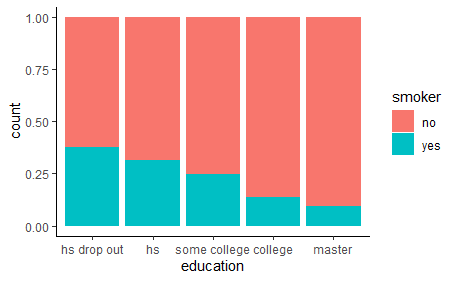

```r
SmokeBan %>% ggplot(aes(fill = smoker, x = education)) +
    geom_bar(position = "fill") +
    theme_classic()
```

Do smoking bans reduce smoking? The estimated coefficient on smoking bans $\hat{\beta}=-0.0455$ suggests that perhaps they do, hough there may be questions of reverse causation here; perhaps non-smokers are more willing to work at non-smoking workplaces than are smokers.

Let’s take another look at the affairs dataset. We predict whether or not an individual had an estramarital affair with gender, whether or not they have kids, education level, length of marriage, and measures of religiosity and their rating of their marital happiness.

```r
reg3a <- glm(affair ~ male + yrsmarr + kids + relig + educ + ratemarr, data = affairs, family = binomial(link = "probit"))
reg3amargins <- margins(reg3a)
export_summs(reg3amargins,
             number_format = "%.4f",
             stars = c(`***` = 0.01, `**` = 0.05, `*` = 0.1))
```

```
no 'nobs' method is available
```

```
          ───────────────────────────────────────────────
                                         Model 1
                                 ────────────────────────
            educ                             0.0032
                                            (0.0076)
            kids                             0.0662
                                            (0.0469)
            male                             0.0347
                                            (0.0365)
            ratemarr                        -0.0772 ***
                                            (0.0144)
            relig                           -0.0544 ***
                                            (0.0145)
            yrsmarr                          0.0065 *
                                            (0.0037)
                                 ────────────────────────
            nobs                             0
            null.deviance                  675.3770
            df.null                        600.0000
            logLik                        -308.0657
            AIC                            630.1314
            BIC                            660.9216
            deviance                       616.1314
            df.residual                    594.0000
            nobs.1                         601.0000
          ───────────────────────────────────────────────
            *** p < 0.01; ** p < 0.05; * p < 0.1.

Column names: names, Model 1
```

As one might expect, happily married and highly religious individuals are less likely to have an affair than otherwise. If we look more deeply at the data descriptions with `data(affairs)`, we see that the religiosity and marital happiness variables are coded as such:

- relig: 5 = very relig., 4 = somewhat, 3 = slightly, 2 = not at all, 1 = anti
- ratemarr: 5 = vry hap marr, 4 = hap than avg, 3 = avg, 2 = smewht unhap, 1 = vry unhap

```r
reg3b <- glm(affair ~ male + yrsmarr + kids + as.factor(relig) + educ + as.factor(ratemarr), data = affairs, family = binomial(link = "probit"))
reg3bmargins <- margins(reg3b)
export_summs(reg3amargins, reg3bmargins,
             number_format = "%.4f",
             stars = c(`***` = 0.01, `**` = 0.05, `*` = 0.1),
             model.names = c("Measured", "Factors"))
```

```
         ─────────────────────────────────────────────────
                             Measured         Factors
                         ─────────────────────────────────
           educ               0.0032          0.0030
                             (0.0076)        (0.0075)
           kids               0.0662          0.0589
                             (0.0469)        (0.0469)
           male               0.0347          0.0362
                             (0.0365)        (0.0364)
           ratemarr          -0.0772 ***
                             (0.0144)
           relig             -0.0544 ***
                             (0.0145)
           yrsmarr            0.0065 *        0.0066 *
                             (0.0037)        (0.0037)
           ratemarr2                          0.0075
                                             (0.1348)
           ratemarr3                         -0.1744
                                             (0.1300)
           ratemarr4                         -0.2290 *
                                             (0.1259)
           ratemarr5                         -0.2970 **
                                             (0.1257)
           relig2                            -0.1983 ***
                                             (0.0759)
           relig3                            -0.1238
                                             (0.0792)
           relig4                            -0.2779 ***
                                             (0.0734)
           relig5                            -0.2718 ***
                                             (0.0814)
                         ─────────────────────────────────
           nobs               0               0
           null.deviance    675.3770        675.3770
           df.null          600.0000        600.0000
           logLik          -308.0657       -302.7147
           AIC              630.1314        631.4294
           BIC              660.9216        688.6111
           deviance         616.1314        605.4294
           df.residual      594.0000        588.0000
           nobs.1           601.0000        601.0000
         ─────────────────────────────────────────────────
           *** p < 0.01; ** p < 0.05; * p < 0.1.

Column names: names, Measured, Factors
```

Let’s work through one more probit example to see how we can estimate marginal effects for specific values of our independent variables. This is especially important for calculating the marginal effects of interaction effects.

Let’s use the `recid` data in the wooldridge package. This data looks at prison recidivism, and the variable `cens` indicates whether or not an individual released from prison wound up back in prison ($cens = 0$) or did not ($cens = 1$) at some point in the next 6-7 years. Let’s suppose we believe that recidivism is influenced by whether or not an individual was in the North Carolina prison work program, and that we suspect the effectiveness of the prison work program is somehow affected by years of education. We will model $cens$ as a function the interaction between the prisoner’s years of education and whether or not the participated in the North Carolina prison work program and other control variables.

```r
reg4a <- glm(cens ~ educ*workprg + age +I(age^2) + drugs + alcohol + black + tserved,
             data = recid,
             family = binomial(link = "probit"))
export_summs(reg4a)
```

```
         ─────────────────────────────────────────────────
                                          Model 1
                                 ─────────────────────────
           (Intercept)                         -0.57
                                               (0.36)
           educ                                -0.00
                                               (0.02)
           workprg                             -0.51
                                               (0.29)
           age                                  0.01 ***
                                               (0.00)
           I(age^2)                            -0.00 **
                                               (0.00)
           drugs                               -0.26 **
                                               (0.08)
           alcohol                             -0.43 ***
                                               (0.09)
           black                               -0.36 ***
                                               (0.07)
           tserved                             -0.01 ***
                                               (0.00)
           educ:workprg                         0.04
                                               (0.03)
                                 ─────────────────────────
           N                                 1445
           AIC                               1833.72
           BIC                               1886.47
           Pseudo R2                            0.10
         ─────────────────────────────────────────────────
           *** p < 0.001; ** p < 0.01; * p < 0.05.

Column names: names, Model 1
```

We see that all of our control variables are significant, but none of our variables of interest are. Next, let’s run the regression object through the `margins()` function to see some easier-to-interpet results:

```r
reg4amargins <- margins(reg4a)
export_summs(reg4amargins,
             number_format = "%.4f",
             stars = c(`***` = 0.01, `**` = 0.05, `*` = 0.1))
```

```
          ───────────────────────────────────────────────
                                         Model 1
                                 ────────────────────────
            age                              0.0010 ***
                                            (0.0002)
            alcohol                         -0.1550 ***
                                            (0.0312)
            black                           -0.1303 ***
                                            (0.0248)
            drugs                           -0.0916 ***
                                            (0.0289)
            educ                             0.0072
                                            (0.0054)
            tserved                         -0.0038 ***
                                            (0.0006)
            workprg                         -0.0302
                                            (0.0267)
                                 ────────────────────────
            nobs                             0
            null.deviance                 1921.9600
            df.null                       1444.0000
            logLik                        -906.8582
            AIC                           1833.7163
            BIC                           1886.4750
            deviance                      1813.7163
            df.residual                   1435.0000
            nobs.1                        1445.0000
          ───────────────────────────────────────────────
            *** p < 0.01; ** p < 0.05; * p < 0.1.

Column names: names, Model 1
```

Of note is that both the quadratic term on $age$ and the interaction effect are not presented here; again, this is to be expected because of the way that marginal effects are calculated.

Finally, to test our hypothesis that there is an interaction between the work program and education, we will use the `at` option in `margins()`. Let’s look at the marginal effects for $educ = 8$, $educ = 12$, and $educ = 16$:

```r
reg4amargins0 <- margins(reg4a, at = list(educ = 8))
reg4amargins1 <- margins(reg4a, at = list(educ = 12))
reg4amargins2 <- margins(reg4a, at = list(educ = 16))
# reg4amargins2 <- margins(reg4a, at = list(educ = 16))
export_summs(reg4amargins, reg4amargins0, reg4amargins1, reg4amargins2,
             number_format = "%.4f",
             stars = c(`***` = 0.01, `**` = 0.05, `*` = 0.1),
             model.names = c("AME", "Education = 8", "Education = 12", "Education = 16"))
```

```
 ──────────────────────────────────────────────────────────────────
                   AME       Education    Education    Education
                                = 8          = 12         = 16
              ─────────────────────────────────────────────────────
   age          0.0010 ***   0.0010 ***   0.0009 ***   0.0009 ***
                (0.0002)     (0.0002)     (0.0002)     (0.0002)

   alcohol         -0.1550      -0.1564      -0.1529      -0.1479
                       ***          ***          ***          ***
                (0.0312)     (0.0315)     (0.0309)     (0.0304)

   black           -0.1303      -0.1315      -0.1286      -0.1244
                       ***          ***          ***          ***
                (0.0248)     (0.0251)     (0.0244)     (0.0239)

   drugs           -0.0916      -0.0924      -0.0904      -0.0874
                       ***          ***          ***          ***
                (0.0289)     (0.0292)     (0.0286)     (0.0280)

   educ         0.0072       0.0073       0.0070       0.0064
                (0.0054)     (0.0055)     (0.0053)     (0.0050)

   tserved         -0.0038      -0.0039      -0.0038      -0.0037
                       ***          ***          ***          ***
                (0.0006)     (0.0006)     (0.0006)     (0.0006)

   workprg      -0.0302         -0.0572   0.0058       0.0654
                                    *
                (0.0267)     (0.0324)     (0.0350)     (0.0664)

              ─────────────────────────────────────────────────────
   nobs         0            0            0            0
   null.devia   1921.9600    1921.9600    1921.9600    1921.9600
   nce
   df.null      1444.0000    1444.0000    1444.0000    1444.0000

   logLik       -906.8582    -906.8582    -906.8582    -906.8582

   AIC          1833.7163    1833.7163    1833.7163    1833.7163

   BIC          1886.4750    1886.4750    1886.4750    1886.4750

   deviance     1813.7163    1813.7163    1813.7163    1813.7163

   df.residua   1435.0000    1435.0000    1435.0000    1435.0000
   l
   nobs.1       1445.0000    1445.0000    1445.0000    1445.0000

 ──────────────────────────────────────────────────────────────────
   *** p < 0.01; ** p < 0.05; * p < 0.1.

Column names: names, AME, Education = 8, Education = 12, Education
= 16
```

As we can see, estimating the marginal effect at differing levels of education reveals that the North Carolina prison work program seems to have a negative and significant effect on individuals with low levels of education. It might also be instructive to estimate the marginal effects for $workprg = 0$ and $workprg = 1$:

```r
reg4amarginsnowork <- margins(reg4a, at = list(workprg = 0))
reg4amarginswork <- margins(reg4a, at = list(workprg = 1))
export_summs(reg4amargins, reg4amarginsnowork, reg4amarginswork,
             number_format = "%.4f",
             stars = c(`***` = 0.01, `**` = 0.05, `*` = 0.1),
             model.names = c("AME", "No Work Program", "Work Program"))
```

```
 ─────────────────────────────────────────────────────────────────
                        AME           No Work      Work Program
                                      Program
                 ─────────────────────────────────────────────────
   age                0.0010 ***      0.0010 ***      0.0010 ***
                     (0.0002)        (0.0002)        (0.0002)
   alcohol           -0.1550 ***     -0.1533 ***     -0.1567 ***
                     (0.0312)        (0.0307)        (0.0318)
   black             -0.1303 ***     -0.1289 ***     -0.1318 ***
                     (0.0248)        (0.0246)        (0.0252)
   drugs             -0.0916 ***     -0.0906 ***     -0.0926 ***
                     (0.0289)        (0.0286)        (0.0293)
   educ               0.0072         -0.0001          0.0157 **
                     (0.0054)        (0.0075)        (0.0074)
   tserved           -0.0038 ***     -0.0038 ***     -0.0039 ***
                     (0.0006)        (0.0006)        (0.0006)
   workprg           -0.0302         -0.0291         -0.0312
                     (0.0267)        (0.0261)        (0.0273)
                 ─────────────────────────────────────────────────
   nobs               0               0               0
   null.deviance   1921.9600       1921.9600       1921.9600
   df.null         1444.0000       1444.0000       1444.0000
   logLik          -906.8582       -906.8582       -906.8582
   AIC             1833.7163       1833.7163       1833.7163
   BIC             1886.4750       1886.4750       1886.4750
   deviance        1813.7163       1813.7163       1813.7163
   df.residual     1435.0000       1435.0000       1435.0000
   nobs.1          1445.0000       1445.0000       1445.0000
 ─────────────────────────────────────────────────────────────────
   *** p < 0.01; ** p < 0.05; * p < 0.1.

Column names: names, AME, No Work Program, Work Program
```

Looked at this way, we can see that education is not a good predictor of recidivism for individuals not in the work program, but it is for individuals in the work program.

### Data for further exploration

- `AER:CreditCard` - model $card$, a binary variable denoting whether or not a credit card application was accepted.
- `AER:HMDA` - model $deny$, looking in particular for discrimination against black borrowers (the $afam$ dummy). Does discrimination go away when controlling for all relevant factors?
- `AER:PSID1976` - model $participation$ as a function of education, age, number of children, family income, etc.
- `AER:ResumeNames` - model $call$, looking in particular for discrimination against individuals with “black names.” This type of analysis is called an “audit study”
- `wooldridge:card` - model $enroll$, a binary measuring whether or not a student enrolled at a college.
- `datasets:Titanic` - model $Survived$, and see if “women and children first” was really a thing! To convert this `Titanic` into something usable by the `glm()` function, use the following code first:

```r
data(Titanic)
tempdata <- as.data.frame(Titanic)
titaniclong <- tempdata[rep(1:nrow(tempdata), tempdata$Freq), -5]
```

# Ordered and Multinomial Probit

If our dependent variable has more than 2 possible levels, then we need to use slightly the more advanced methods of *Ordered Probit* and/or *Multinomial Probit*. If the levels of our dependent variable are ordered, we use *ordered probit*, and if they are unordered, we use *multinomial probit*. Generally speaking, these two models are far more advanced than the probit models we saw above, so we will only briefly look at these models.

Some applications of ordered probit might include:

- Your dependent variable is a Likert scale (e.g. the responses are strongly disagree, disagree, …, strongly agree).
- You are modeling purchase decisions on a scale (e.g. does a visitor to Disney World stay at a value resort, moderate resort, or luxury resort?).
- Sometimes all you have is ordered data even if numeric data in principal exists, such as education level, income level, etc.

By contrast, muntinomial probit would be called for in situations where the response variable doesn’t have a natural ordering:

- You are modeling an unordered purchase decision, such as whether or not somebody purchased a Xbox Series X, PS5, or Nintendo Switch.
- You are modeling individual preferences (e.g. you survey people and ask them their favorite fast food restaurant).

Let’s work through one example of an ordered probit. A warning: interpreting the coefficients on these models is very tricky; we will focus on interpreting signs and significance, but interpreting magnitudes will be left as an advanced exercise for the interested student.

The command for an ordered probit, `polr()`, is part of the `MASS` package, so if you haven’t run `install.packages("MASS")` and/or `library(MASS)`, now is the time. We will make use of the `housing` dataset contained within the `MASS` package.

```r
data(housing)
head(housing)
```

|  | Sat | Infl | Type | Cont | Freq |
| --- | --- | --- | --- | --- | --- |
| 1 | Low | Low | Tower | Low | 21 |
| 2 | Medium | Low | Tower | Low | 21 |
| 3 | High | Low | Tower | Low | 28 |
| 4 | Low | Medium | Tower | Low | 34 |
| 5 | Medium | Medium | Tower | Low | 22 |
| 6 | High | Medium | Tower | Low | 36 |

The variable $Sat$ measures housing satisfaction on an ordered scale, so an ordered probit model is appropriate here. Note that the unusual coding of the data requires us to use the `weights = Freq` option.

```r
reg5a <- polr(Sat ~ Infl + Type + Cont, weights = Freq, data = housing, method = "probit")
summary(reg5a)
```

```
Call:
polr(formula = Sat ~ Infl + Type + Cont, data = housing, weights = Freq,
    method = "probit")

Coefficients:
                Value Std. Error t value
InflMedium     0.3464    0.06414   5.401
InflHigh       0.7829    0.07643  10.244
TypeApartment -0.3475    0.07229  -4.807
TypeAtrium    -0.2179    0.09477  -2.299
TypeTerrace   -0.6642    0.09180  -7.235
ContHigh       0.2224    0.05812   3.826

Intercepts:
            Value   Std. Error t value
Low|Medium  -0.2998  0.0762    -3.9371
Medium|High  0.4267  0.0764     5.5850

Residual Deviance: 3479.689
AIC: 3495.689
```

Essentially, the ordered probit model estimates the probability of each of the possible outcome values at the same time, and assigns a probability to each outcome. Because the order of the dependent variable is from worst appraisal of housing satisfaction ($Sat = Low$) to the highest appraisal ($Sat = High$), we interpret negative coefficients as reducing somebody’s appraisal of their housing satisfaction. Since these independent variables are dummies, we interpret them as before, with reference to the omitted variable. Finally, while there are no stars here, we can use t-values to get the same information about significance. A good rule of thumb is that a t-value greater than 2 (or less than -2) indicates a statistically significant coefficient.

This model generates multiple predicted probabilities – one for each of the possible values of the dependent variable. Here, the ordered probit generates 3 such probabilities. The predicted value for an observation, then, is the outcome with the highest probability of occurring. We can take a look at the predicted values for each observation with the following code:

```r
temphousing <- predict(reg5a, housing, type = "probs")
temphousing <- as.data.frame(temphousing)
temphousing <- temphousing %>%
    bind_cols(housing) %>%
    filter(Sat == "Low") %>%
    select(- c(Sat,Freq))
tibble(temphousing)
```

| Low | Medium | High | Infl | Type | Cont |
| --- | --- | --- | --- | --- | --- |
| 0.38215396 | 0.2830551 | 0.3347909 | Low | Tower | Low |
| 0.25905831 | 0.2729421 | 0.4679996 | Medium | Tower | Low |
| 0.13946131 | 0.2213870 | 0.6391517 | High | Tower | Low |
| 0.51902561 | 0.2615855 | 0.2193889 | Low | Apartment | Low |
| 0.38257895 | 0.2830358 | 0.3343852 | Medium | Apartment | Low |
| 0.23110703 | 0.2654400 | 0.5034530 | High | Apartment | Low |
| 0.46734683 | 0.2730631 | 0.2595901 | Low | Atrium | Low |
| 0.33419318 | 0.2830266 | 0.3827803 | Medium | Atrium | Low |
| 0.19355915 | 0.2514407 | 0.5550001 | High | Atrium | Low |
| 0.64219981 | 0.2201408 | 0.1376594 | Low | Terrace | Low |

[output cut: 14 more lines]

```r
NA
```

### Data for further exploration

- The `fivethirtyeight` dataset `steak_survey` has an interesting ordinal variable, $steak\_prep$, which comes from a survey of how well done Americans like their steak.
- The `comma_survey` in the `fivethirtyeight` dataset includes a variable called $care\_proper\_grammar$ that is a likert scale on how much people care about proper use of grammar.

# Wrapping Up

Probit and logit models are a valuable addition to our econometric skillset as they allow us to extend our data skills into explaining categorical phenonema. We have also looked briefly at the ordinal and multinomial versions of probit and logit; while the programming skills requried for these models is a bit beyond the scope of the class, I hope that you can see their potential usefulness.

Next, we turn to models for censored and count variables.